# Sentiment analyis using Naive Bayes Classification

Once both classifiers are trained, we can utilise the models to classify our 'new', unannotated data. This is where the actual sentiment analysis will happen.

## Getting the Corpus

- Positive
- Negative
- Neutral
- Irrelevant

and by topic:

- Apple
- Google
- Microsoft
- Twitter

The csv file containing this data is retrieved from:

https://github.com/zfz/twitter_corpus/blob/master/full-corpus.csv

```python
import pandas as pd

df = pd.read_csv('data/full-corpus.csv')
```

```python
import numpy as np

df['Opinion'] = np.where(df['Sentiment'].isin(['positive','negative']),'opinion','no opinion')
df.head()
```

|  | Topic | Sentiment | TweetId | TweetDate | TweetText | Opinion |
| --- | --- | --- | --- | --- | --- | --- |
| 0 | apple | positive | 126415614616154112 | Tue Oct 18 21:53:25 +0000 2011 | Now all @Apple has to do is get swype on the i... | opinion |
| 1 | apple | positive | 126404574230740992 | Tue Oct 18 21:09:33 +0000 2011 | @Apple will be adding more carrier support to ... | opinion |
| 2 | apple | positive | 126402758403305474 | Tue Oct 18 21:02:20 +0000 2011 | Hilarious @youtube video - guy does a duet wit... | opinion |
| 3 | apple | positive | 126397179614068736 | Tue Oct 18 20:40:10 +0000 2011 | @RIM you made it too easy for me to switch to ... | opinion |
| 4 | apple | positive | 126395626979196928 | Tue Oct 18 20:34:00 +0000 2011 | I just realized that the reason I got into twi... | opinion |

```python
import plotly.graph_objects as go
from plotly.subplots import make_subplots


fig = make_subplots(rows=1,cols=3,subplot_titles = ['Topic','Opinion','Sentiment'])

fig.append_trace(go.Bar(y=df.Topic.value_counts(),x = df.Topic.value_counts().index,name = 'Topic'),row=1,col=1)
fig.append_trace(go.Bar(y=df.Opinion.value_counts(),x = df.Opinion.value_counts().index,name = 'Opinion'),row=1,col=2)
fig.append_trace(go.Bar(y=df.Sentiment.value_counts(),x = df.Sentiment.value_counts().index,name = 'Sentiment'),row=1,col=3)

fig.update_layout(template = 'plotly_white',showlegend = False,yaxis_title = 'Count')

fig.show()
```

[interactive chart not shown]

## Preprocessing the Data

In order to use the tweet's text in a naive bayes classifier (and any machine learning algorithm for that matter), the tweets must be cleaned of punctuation, special characters, links & single characters which remain as remnants from removing accentuations (such as *he's* would become *he* and *s* so we aim to remove the *s*) by the use of regular expressions.

To do this, we make use of python's regular expression method 're' and define a method that substitutes all of the aforementioned characters:

```python
import re

def clean_tweets(sentence):
    # Remove all the special characters
    processed_feature = re.sub(r'\W', ' ', str(sentence))

    # Remove all single characters
    processed_feature= re.sub(r'\s+[a-zA-Z]\s+', ' ', processed_feature)

    # Remove single characters from the start
    processed_feature = re.sub(r'\^[a-zA-Z]\s+', ' ', processed_feature)

    # Substituting multiple spaces with single space
    processed_feature = re.sub(r'\s+', ' ', processed_feature, flags=re.I)

    # Removing prefixed 'b'
    processed_feature = re.sub(r'^b\s+', '', processed_feature)

     # Converting to Lowercase
    processed_feature = processed_feature.lower()

    return str(processed_feature)
```

```python
df['TweetText'] = df['TweetText'].map(clean_tweets)
df.head()
```

|  | Topic | Sentiment | TweetId | TweetDate | TweetText | Opinion |
| --- | --- | --- | --- | --- | --- | --- |
| 0 | apple | positive | 126415614616154112 | Tue Oct 18 21:53:25 +0000 2011 | now all apple has to do is get swype on the ip... | opinion |
| 1 | apple | positive | 126404574230740992 | Tue Oct 18 21:09:33 +0000 2011 | apple will be adding more carrier support to ... | opinion |
| 2 | apple | positive | 126402758403305474 | Tue Oct 18 21:02:20 +0000 2011 | hilarious youtube video guy does duet with app... | opinion |
| 3 | apple | positive | 126397179614068736 | Tue Oct 18 20:40:10 +0000 2011 | rim you made it too easy for me to switch to ... | opinion |
| 4 | apple | positive | 126395626979196928 | Tue Oct 18 20:34:00 +0000 2011 | i just realized that the reason got into twitt... | opinion |

## Creating Features

A simple application of the Naive Bayes classifier works as follows, we are trying to predict p(positive|Features) of a tweet.

the features in this case, are the frequencies of the words within a tweet. For this reason, a document term matrix (DTM) must be created. The *CountVectorizer* method of the scikit-learn module is used to do so. The *CountVectorizer* method also contains a stop_words argument for which we can pass a list of stopwords to exclude from the DTM, we use the list of stopwords provided by the *NLTK* module.

```python
features = df['TweetText']
labels = df['Opinion']
```

## Preparing Features for Training

The data is first split into a train/test set by 80/20 proportions.

```python
from sklearn.model_selection import train_test_split

X_train, X_test, y_train, y_test = train_test_split(features, labels, test_size=0.2, random_state=2)
```

To prepare the features for training our classifier, we must first adress the imbalanced class issue. As illustrated before, the opinion to non opinion classes have proportions of 35% and 65% respectively. We use a random oversampling technique to balance the data by randomly copying the underrepresented (opinion) class data.

## Opinion Classifier Training

### 1. Naive Bayes Classifier

We are now able to train our Multinomial Naive Bayes classifier, using the *MultinomialNB* method provided in the scikit-learn module:

```python
from nltk.corpus import stopwords
from sklearn.feature_extraction.text import CountVectorizer
from imblearn.pipeline import Pipeline
from imblearn.over_sampling import RandomOverSampler
from sklearn.naive_bayes import MultinomialNB

def Tokenizer(str_input):
    words = re.sub(r"[^A-Za-z0-9\-]", " ", str_input).lower().split()
    porter_stemmer = nltk.PorterStemmer()
    words = [porter_stemmer.stem(word) for word in words]
    return words

vect = CountVectorizer(max_features=2500, min_df=7, max_df=0.8, stop_words=stopwords.words('english')).fit(X_train)
ros = RandomOverSampler(random_state=0)
MNB_clf = MultinomialNB()


mnb_opinion_pipeline = Pipeline(steps=[
  ('vectorize', vect),
  ('oversample',ros),
  ('classify', MNB_clf)
])

mnb_opinion_pipeline.fit(X_train,y_train)
mnb_opinion_pred = mnb_opinion_pipeline.predict(X_test)
```

In order to evaluate our model, we print a classification report including a confusion matrix, accuracy score & ROC curve.

```python
from sklearn import metrics
import seaborn as sns
import matplotlib.pyplot as plt


def evaluate_model(classifier,X_test,y_test,y_pred,pos_label):
    print(metrics.classification_report(y_test,y_pred))
    print('accuracy score: ',metrics.accuracy_score(y_test, y_pred))

    #plot confusion matrix
    cm = metrics.confusion_matrix(y_test,y_pred)
    pred_labels = classifier.classes_
    plt.figure(figsize = (15,5))
    ax= plt.subplot(1,2,1)
    sns.heatmap(cm, annot=True, ax = ax,cmap='Blues',fmt='g');
    ax.set_xlabel('Predicted labels');ax.set_ylabel('Actual labels');
    ax.set_title('Confusion Matrix');
    ax.xaxis.set_ticklabels(pred_labels);
    ax.yaxis.set_ticklabels(pred_labels);

    #plot ROC matrix
    scores = classifier.predict_proba(X_test)
    fpr, tpr, thresholds = metrics.roc_curve(y_test, scores[:,1], pos_label= pos_label)
    plt.subplot(1,2,2)
    plt.plot(fpr,tpr, color = 'red')
    plt.plot([0, 1], [0, 1], color='navy', lw=2, linestyle='--')
    plt.xlabel('False Positive Rate')
    plt.ylabel('True Positive Rate')
    plt.tight_layout()
```

```
              precision    recall  f1-score   support

  no opinion       0.96      0.69      0.80       195
     opinion       0.58      0.93      0.72        91

    accuracy                           0.77       286
   macro avg       0.77      0.81      0.76       286
weighted avg       0.84      0.77      0.77       286

accuracy score:  0.7657342657342657
```

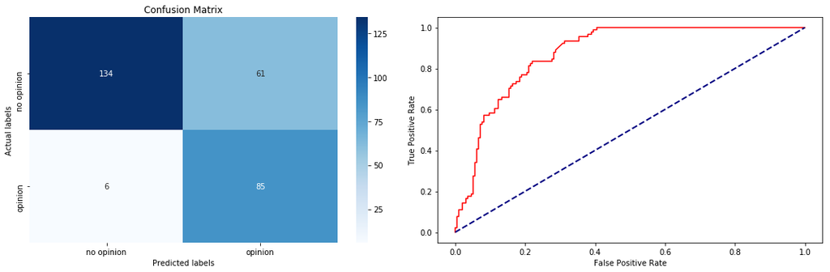

```python
evaluate_model(mnb_opinion_pipeline,X_test,y_test,mnb_opinion_pred,'opinion')
```

### 2. SVM Classifier

The same is done but by using a SVM classifier

```python
from nltk.corpus import stopwords
from sklearn.feature_extraction.text import CountVectorizer
from imblearn.pipeline import Pipeline
from imblearn.over_sampling import RandomOverSampler
from sklearn.svm import SVC


SVM_clf = SVC(kernel='linear',probability = True)

svm_opinion_pipeline = Pipeline(steps=[
  ('vectorize', vect),
  ('oversample',ros),
  ('classify', SVM_clf)
])

svm_opinion_pipeline.fit(X_train,y_train)
svm_opinion_pred = svm_opinion_pipeline.predict(X_test)
```

```
              precision    recall  f1-score   support

  no opinion       0.91      0.76      0.83       195
     opinion       0.63      0.85      0.72        91

    accuracy                           0.79       286
   macro avg       0.77      0.81      0.78       286
weighted avg       0.82      0.79      0.80       286

accuracy score:  0.7902097902097902
```

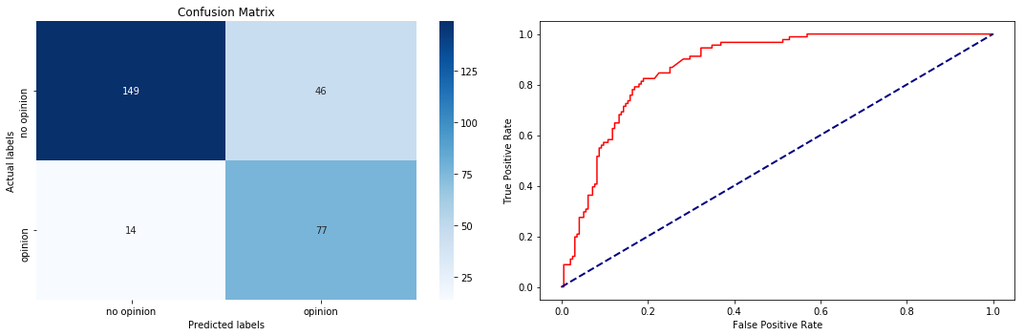

```python
evaluate_model(svm_opinion_pipeline,X_test,y_test,svm_opinion_pred,'opinion')
```

# Sentiment Training

## Filter data for opinionated tweets only

```python
opinion_df = df[df['Opinion'] == 'opinion']
opinion_df.head()
```

|  | Topic | Sentiment | TweetId | TweetDate | TweetText | Opinion |
| --- | --- | --- | --- | --- | --- | --- |
| 0 | apple | positive | 126415614616154112 | Tue Oct 18 21:53:25 +0000 2011 | now all apple has to do is get swype on the ip... | opinion |
| 1 | apple | positive | 126404574230740992 | Tue Oct 18 21:09:33 +0000 2011 | apple will be adding more carrier support to ... | opinion |
| 2 | apple | positive | 126402758403305474 | Tue Oct 18 21:02:20 +0000 2011 | hilarious youtube video guy does duet with app... | opinion |
| 3 | apple | positive | 126397179614068736 | Tue Oct 18 20:40:10 +0000 2011 | rim you made it too easy for me to switch to ... | opinion |
| 4 | apple | positive | 126395626979196928 | Tue Oct 18 20:34:00 +0000 2011 | i just realized that the reason got into twitt... | opinion |

## Create features, balance data & subset train/test data

```python
features = opinion_df['TweetText']
labels = opinion_df['Sentiment']
```

```python
X_train, X_test, y_train, y_test = train_test_split(features, labels, test_size=0.2, random_state=0)
```

### 1. Naive Bayes Classifier

```
              precision    recall  f1-score   support

    negative       0.87      0.85      0.86        62
    positive       0.76      0.78      0.77        37

    accuracy                           0.83        99
   macro avg       0.82      0.82      0.82        99
weighted avg       0.83      0.83      0.83        99

accuracy score:  0.8282828282828283
```

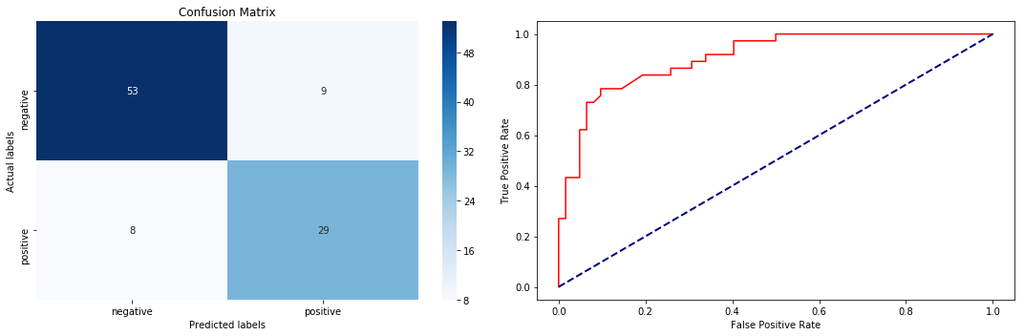

```python
vect = CountVectorizer(max_features=2500, min_df=7, max_df=0.8, stop_words=stopwords.words('english')).fit(X_train)
ros = RandomOverSampler(random_state=0)
MNB_clf = MultinomialNB()


mnb_sentiment_pipeline = Pipeline(steps=[
  ('vectorize', vect),
  ('oversample',ros),
  ('classify', MNB_clf)
])

mnb_sentiment_pipeline.fit(X_train,y_train)
mnb_sentiment_pred = mnb_sentiment_pipeline.predict(X_test)


evaluate_model(mnb_sentiment_pipeline,X_test,y_test,mnb_sentiment_pred,'positive')
```

### 2. SVM Classifier

```
              precision    recall  f1-score   support

    negative       0.84      0.82      0.83        62
    positive       0.71      0.73      0.72        37

    accuracy                           0.79        99
   macro avg       0.77      0.78      0.77        99
weighted avg       0.79      0.79      0.79        99

accuracy score:  0.7878787878787878
```

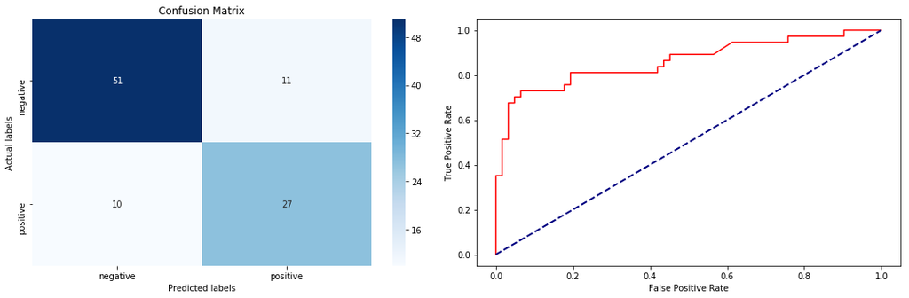

```python
SVM_clf = SVC(kernel='linear',probability = True)

svm_sentiment_pipeline = Pipeline(steps=[
  ('vectorize', vect),
  ('oversample',ros),
  ('classify', SVM_clf)
])

svm_sentiment_pipeline.fit(X_train,y_train)
svm_sentiment_pred = svm_sentiment_pipeline.predict(X_test)

evaluate_model(svm_sentiment_pipeline,X_test,y_test,svm_sentiment_pred,'positive')
```

## Retrieve Reddit Comment

The PRAW module is used to interact with Reddit's API by using Python

```python
import praw

def get_reddit_comments(post_id):
    reddit = praw.Reddit(client_id='client-id',                    #define API credentials using your personal keys (obtained after creating application on reddit) and reddit username and password
                         client_secret='client-secret',
                         password='password.',
                         user_agent='user_agent name',
                         username='reddit username')

    submission = reddit.submission(id = post_id)                   # create API connection to a certain reddit post
    submission.comments.replace_more(limit= None)                       # 'limit = None' makes sure that only the top level comments are parsed
    postlist = []                                                       # create empty matrix in which the for loop will write the following attributes:
    for top_level_comment in submission.comments:                       # Author (comment poster), Body (text), and Score (net karma) for each top-level comment entry
        post = {}
        post['Author'] = top_level_comment.author
        post['Comment'] = top_level_comment.body
        post['Score'] = top_level_comment.score
        postlist.append(post)

    return pd.DataFrame(postlist)                                         #return List as DataFrame
```

Run this cell to collect Reddit comments by providing the thread's 'id' in this case 'd2bo6a' as input and save the output as a csv file to access it a later point in time.

```python
#df_comments = get_reddit_comments('d2bo6a')
#df_comments.to_csv('comment_dataframe.csv')
```

Apply the 'Opinion' SVM classifier to all the data

```python
eleven_comments = pd.read_csv('data/comment_output.csv',index_col = 0)
eleven_comments['Predictions'] = eleven_comments[['Comment']].apply(svm_opinion_pipeline.predict)
eleven_comments
```

|  | Author | Comment | subreddit ID | Predictions |
| --- | --- | --- | --- | --- |
| 0 | facemelt | *"fuck everything, we're doing 5 blades"* | coi2x3 | opinion |
| 1 | randomiraqi | Pro sounds much better than Max (still can't b... | coi2x3 | opinion |
| 2 | LogicUpgrade | This name is terrible, so it must be real.\n\n... | coi2x3 | no opinion |
| 3 | wwabc | I'll stick with the Amateur iPhone! | coi2x3 | opinion |
| 4 | Zackeizer | I think they should follow the automotive indu... | coi2x3 | opinion |
| ... | ... | ... | ... | ... |
| 2433 | Tennouheika | I generally like Michael Fischer but it’s very... | dwxd7j | opinion |
| 2434 | bwjxjelsbd | At the end of the day most people will choose ... | dwxd7j | opinion |
| 2435 | TheJadedSF | It’s too fucking heavy and slippery. | dwxd7j | opinion |
| 2436 | aspirexjs | I liked how some Android users are getting pis... | dwxd7j | opinion |
| 2437 | omarsoso | no | dwxd7j | no opinion |

2438 rows × 4 columns

Collect a random sample of 100 entries to manually evaluate the predictions

```python
eleven_comments.sample(100).to_csv('sample.csv')
```

Let's see how many of the Reddit comments got predicted to have an 'opinion' vs 'no opinion'

```python
fig = go.Figure([go.Bar(y=eleven_comments.Predictions.value_counts(),
                        x = eleven_comments.Predictions.value_counts().index)])
fig.show()
```

[interactive chart not shown]

```python
eleven_comments = eleven_comments[eleven_comments['Predictions'] == 'opinion'].copy()
eleven_comments['sentiment']=eleven_comments[['Comment']].apply(mnb_sentiment_pipeline.predict)
eleven_comments.to_csv('eleven_comments.csv')
```

```python
fig = go.Figure([go.Bar(y=eleven_comments.sentiment.value_counts(),
                        x = eleven_comments.sentiment.value_counts().index)])
fig.show()
```

[interactive chart not shown]

```python
import plotly.graph_objects as go
animals=['iPhone 11', 'iPhone XS', 'iPhone X','iPhone 7']

fig = go.Figure(data=[
    go.Bar(name="Actual 'Negative' P", x=animals, y=[0.74, 0.72, 0.84,0.69])
])
# Change the bar mode
fig.update_layout(barmode='group', yaxis_tickformat = '%')
fig.show()
```

[interactive chart not shown]